# COMSOL Dean flow simulation summary

Author

Alistair Bailey

Published

February 20, 2025

## Simulations Overview

1. Rectangular channel (Figure 1): 10 mm length
2. Serpentine channel with two bends (Figure 2): Radius of 280 µm
3. Serpetine channel with four bends (Figure 3): Radius of 280 µm
4. Asymmetric serpentine channel (Figure 4): Approximately 3 mm centreline length (I haven’t figured out how to measure it!)
- All the channels had a rectangular cross section with 2:1 aspect ratio.
- Following solving of the stationary solution, 500 particles of 5 nm diameter were released at the velocities in Table 1.
- The particle counter was the outlet at the end of the channel.
- `t_particle` is an auxiliary variable used in particle tracing simulations. It represents the time a particle has spent in the simulation domain since its release.

Table 1: Particle Simulations

| Channel | Length | Width | Height | Velocities (m.s<sup>-1</sup>) |
| --- | --- | --- | --- | --- |
| Rectangular | 10 mm | 140 µm | 70 µm | 0.2, 0.4, 0.6, 0.8, 1 |
| Serpentine 2-bend | 2.64 mm (centerline) | 140 µm | 70 µm | 0.1, 0.2, 0.3, 0.4, 0.5, 0.6, 0.7, 0.8, 0.9, 1.0 |
| Serpentine 4-bend | 5.28 mm (centerline) | 140 µm | 70 µm | 0.1, 0.2, 0.3, 0.4, 0.5, 0.6, 0.7, 0.8, 0.9, 1.0 |
| Asymmetric serpentine | ~ 3mm (centerline) | 140 µm | 70 µm | 0.1, 0.2, 0.3, 0.4, 0.5, 0.6, 0.7, 0.8, 0.9, 1.0 |

Serpentine channel:

- Centerline radius: 280 - (140/2) = 210 μm
- Centreline length per 180° turn: π × 210 μm = 659.73 μm
- Centreline length per S-curve: 2 × 659.73 = 1319.47 μm

### Retangular

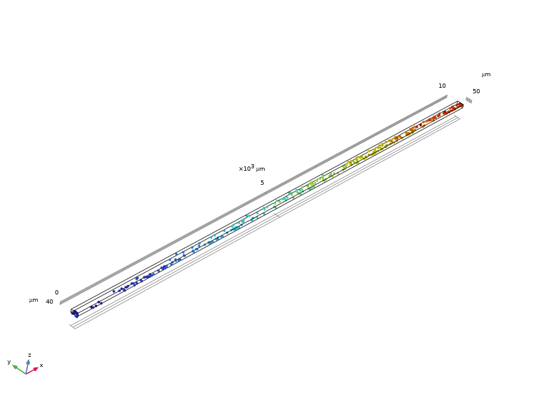

Figure 1: Rectangular Channel 10 mm

### Serpentine 2-bend

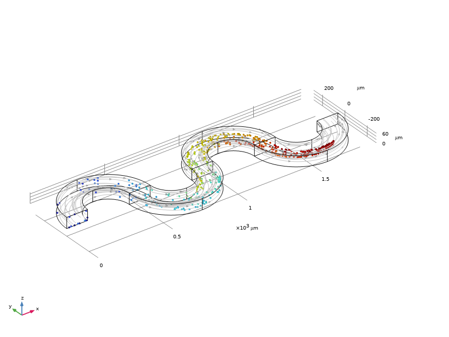

Figure 2: Serpentine Channel with two bends

### Serpentine 4-bend

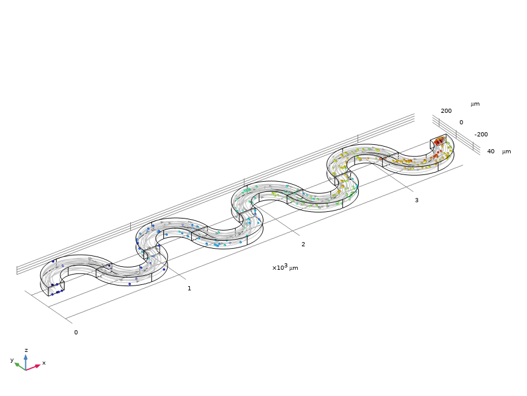

Figure 3: Serpentine Channel with four bends

### Asymmetric

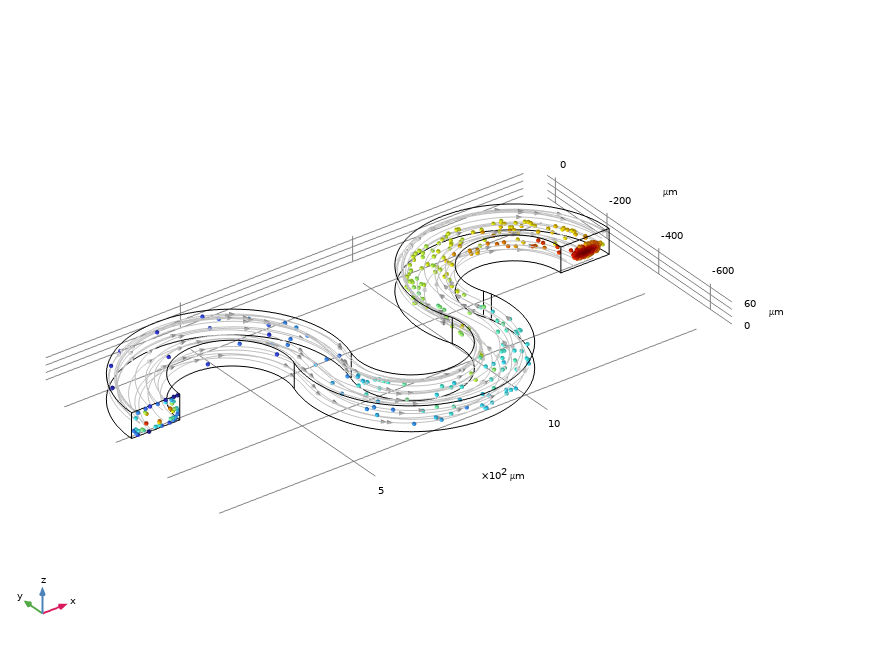

Figure 4: Asymmetric Channel

## Results

As plots all show skewed distributions, I think the geometric mean residence time and log-normal coefficient of variation are the appropriate statistics, but I calculated the arithmetic mean and sample standard deviation CV too just in case I’m wrong (Table 2, Table 3, Table 4, Table 5).

### Particle residence time distributions

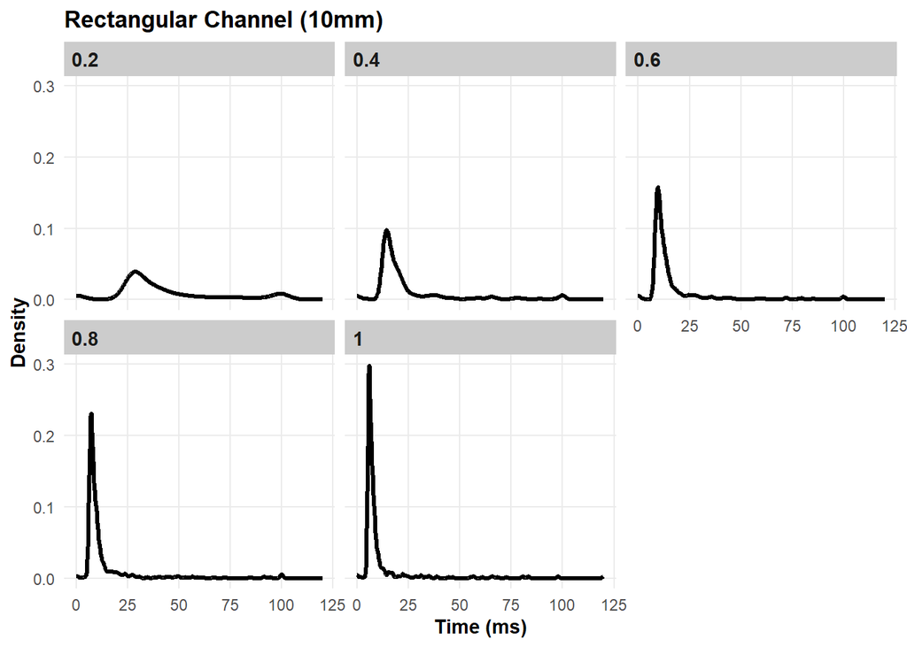

Figure 5: Rectangular Channel (10mm) Particle residence time distribution

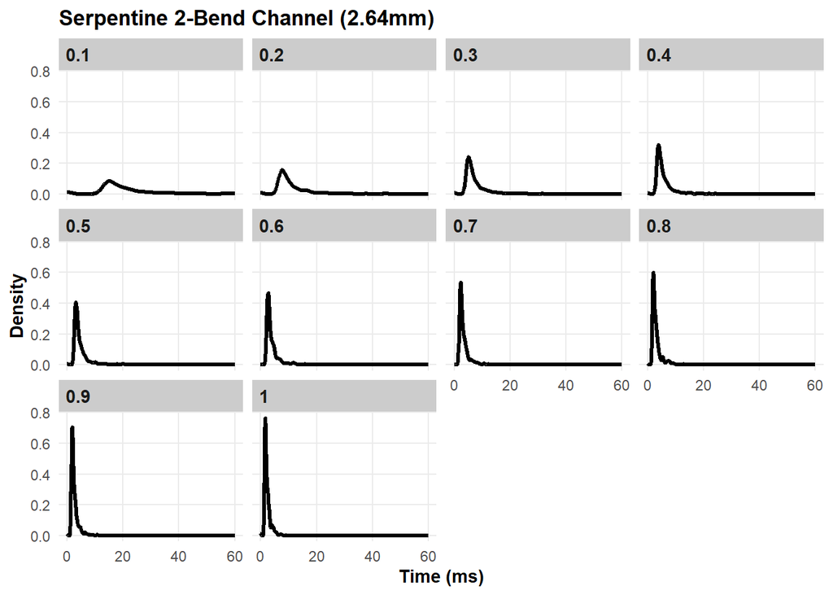

Figure 6: Serpentine 2-Bend Channel (2.64mm) Particle residence time distribution

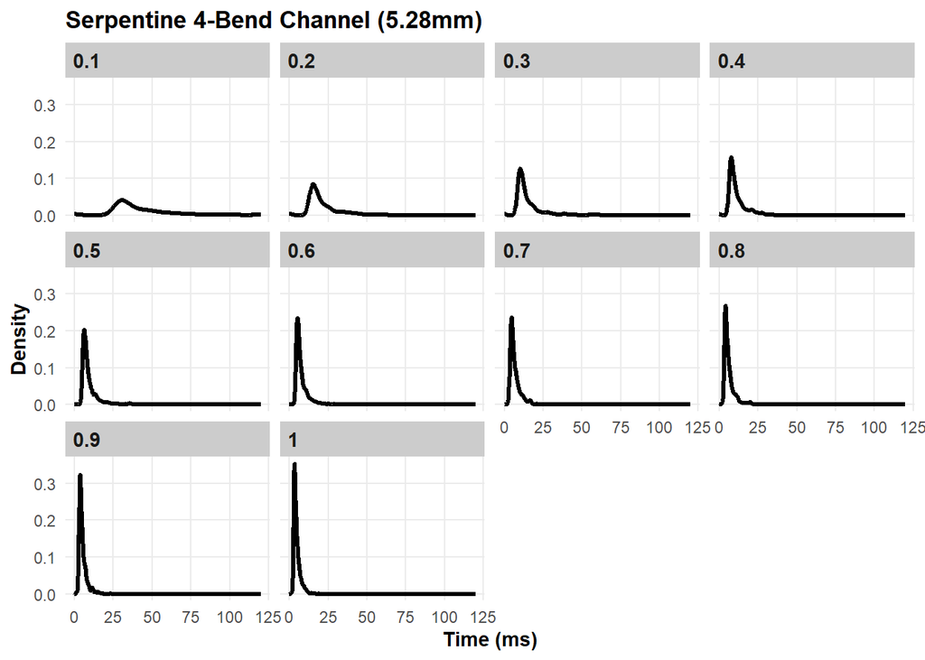

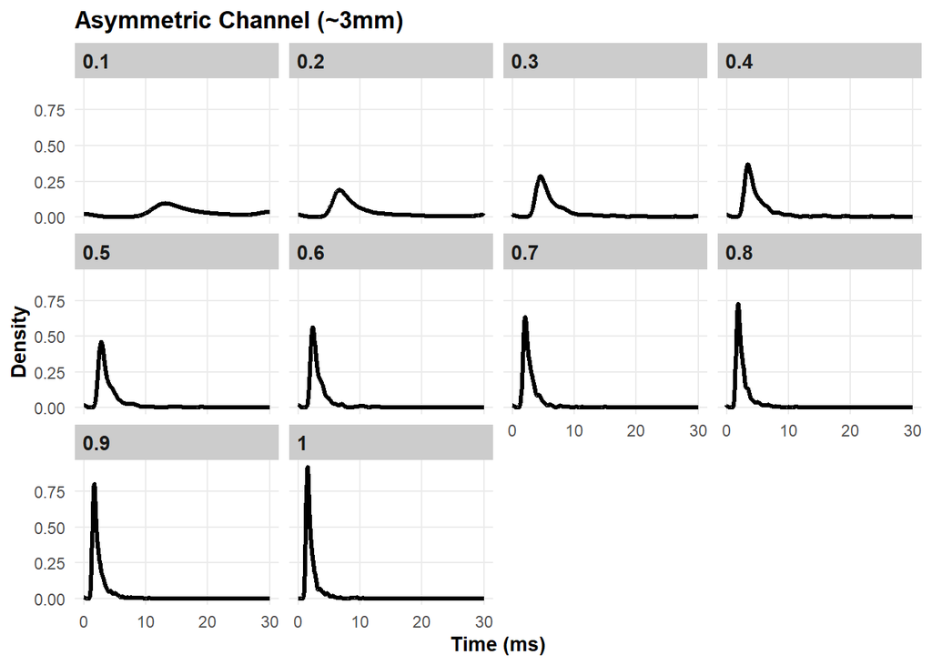

Figure 8: Asymmetric Channel (~3mm) Particle residence time distribution

### Particle residence time statistics

Table 2: Summary Statistics: Rectangular Channel (10mm)

| Velocity (m/s) | Mean Res. Time (ms) | SD Res.Time | Geometric Mean Res.Time (ms) | Median Res. Time (ms) | CV (%) | SD Log Time | CV Log (%) |
| --- | --- | --- | --- | --- | --- | --- | --- |
| 0.2 | 42.28 | 25.10 | 41.99 | 33.78 | 59.37 | 0.0238 | 2.38 |
| 0.4 | 24.07 | 19.94 | 23.88 | 16.70 | 82.84 | 0.0190 | 1.90 |
| 0.6 | 16.50 | 16.38 | 16.37 | 11.11 | 99.29 | 0.0157 | 1.57 |
| 0.8 | 12.66 | 14.42 | 12.57 | 8.31 | 113.85 | 0.0138 | 1.38 |
| 1.0 | 10.78 | 14.35 | 10.68 | 6.69 | 133.14 | 0.0138 | 1.38 |

Table 3: Summary Statistics: Serpentine 2-Bend Channel (2.64mm)

| Velocity (m/s) | Mean Res. Time (ms) | SD Res.Time | Geometric Mean Res.Time (ms) | Median Res. Time (ms) | CV (%) | SD Log Time | CV Log (%) |
| --- | --- | --- | --- | --- | --- | --- | --- |
| 0.1 | 20.64 | 11.19 | 20.58 | 17.61 | 54.19 | 0.0109 | 1.09 |
| 0.2 | 11.56 | 7.32 | 11.53 | 9.04 | 63.35 | 0.0072 | 0.72 |
| 0.3 | 7.63 | 4.55 | 7.62 | 6.06 | 59.63 | 0.0045 | 0.45 |
| 0.4 | 5.89 | 3.88 | 5.88 | 4.59 | 65.90 | 0.0038 | 0.38 |
| 0.5 | 4.85 | 3.42 | 4.84 | 3.66 | 70.51 | 0.0034 | 0.34 |
| 0.6 | 4.03 | 2.49 | 4.03 | 3.11 | 61.61 | 0.0025 | 0.25 |
| 0.7 | 3.48 | 2.31 | 3.48 | 2.70 | 66.21 | 0.0023 | 0.23 |
| 0.8 | 3.03 | 1.69 | 3.02 | 2.42 | 55.92 | 0.0017 | 0.17 |
| 0.9 | 2.62 | 1.40 | 2.62 | 2.13 | 53.38 | 0.0014 | 0.14 |
| 1.0 | 2.35 | 1.14 | 2.35 | 1.93 | 48.62 | 0.0011 | 0.11 |

Table 4: Summary Statistics: Serpentine 4-Bend Channel (5.28mm)

| Velocity (m/s) | Mean Res. Time (ms) | SD Res.Time | Geometric Mean Res.Time (ms) | Median Res. Time (ms) | CV (%) | SD Log Time | CV Log (%) |
| --- | --- | --- | --- | --- | --- | --- | --- |
| 0.1 | 42.83 | 21.69 | 42.61 | 35.27 | 50.64 | 0.0205 | 2.05 |
| 0.2 | 22.09 | 12.02 | 22.02 | 17.74 | 54.42 | 0.0116 | 1.16 |
| 0.3 | 15.16 | 9.32 | 15.11 | 11.97 | 61.51 | 0.0091 | 0.91 |
| 0.4 | 11.52 | 6.45 | 11.50 | 9.25 | 55.98 | 0.0063 | 0.63 |
| 0.5 | 9.28 | 5.32 | 9.27 | 7.36 | 57.25 | 0.0052 | 0.52 |
| 0.6 | 7.77 | 4.29 | 7.76 | 6.27 | 55.26 | 0.0042 | 0.42 |
| 0.7 | 6.85 | 3.42 | 6.84 | 5.65 | 49.93 | 0.0034 | 0.34 |
| 0.8 | 6.20 | 3.38 | 6.20 | 5.04 | 54.45 | 0.0033 | 0.33 |
| 0.9 | 5.22 | 2.69 | 5.21 | 4.34 | 51.56 | 0.0027 | 0.27 |
| 1.0 | 4.73 | 2.28 | 4.73 | 3.98 | 48.17 | 0.0023 | 0.23 |

Table 5: Summary Statistics: Asymmetric Channel (~3mm)

| Velocity (m/s) | Mean Res. Time (ms) | SD Res.Time | Geometric Mean Res.Time (ms) | Median Res. Time (ms) | CV (%) | SD Log Time | CV Log (%) |
| --- | --- | --- | --- | --- | --- | --- | --- |
| 0.1 | 16.48 | 7.73 | 16.45 | 14.80 | 46.89 | 0.0076 | 0.76 |
| 0.2 | 9.73 | 5.70 | 9.72 | 7.77 | 58.54 | 0.0056 | 0.56 |
| 0.3 | 6.71 | 4.35 | 6.70 | 5.27 | 64.82 | 0.0043 | 0.43 |
| 0.4 | 5.17 | 3.53 | 5.17 | 4.00 | 68.27 | 0.0035 | 0.35 |
| 0.5 | 4.21 | 2.93 | 4.20 | 3.24 | 69.73 | 0.0029 | 0.29 |
| 0.6 | 3.48 | 2.27 | 3.48 | 2.71 | 65.17 | 0.0023 | 0.23 |
| 0.7 | 2.99 | 1.87 | 2.99 | 2.40 | 62.61 | 0.0019 | 0.19 |
| 0.8 | 2.69 | 1.61 | 2.69 | 2.14 | 59.86 | 0.0016 | 0.16 |
| 0.9 | 2.38 | 1.28 | 2.38 | 1.93 | 53.94 | 0.0013 | 0.13 |
| 1.0 | 2.15 | 1.20 | 2.15 | 1.74 | 55.99 | 0.0012 | 0.12 |